# Nash Equilibria

with Connor T. Wiegand

## Best Responses

### Last time

- We got a mathy def. of best responses
- Go there
- Function vs. Correspondence
- Some comments on choice in mathematics
- What does it mean?

### Visualization of $BR(\cdot)$

This photo shows some examples of maps (“functions”) in set theory. Think of $S$ as being the set of opponents strategies, and think of $A$ as being the set of your strategies. Any of these could be valid BR functions.

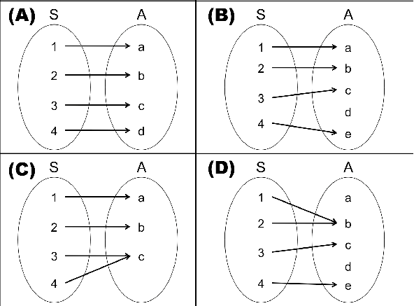

- See next slide for more details

### Visualization of $BR(\cdot)$ (cont.)

- In words: the Best response function
  - Takes a particular strategy profile *from your opponents’ strategies* as an input
  - Spits out your best response
- What is a “best response”?
  - something that’s at least as good as anything else you can do, *given the same input*
- put 2 + 2 together
  - Your best response function takes an opponents’ strategy [profile] as an input, and outputs a subset of your strategies which are at least as good as all the others, if not better.
  - E.g…(see next slide)

### Recall: Best Response Definition

A **Best Response Correspondence** (or function) is a map for player $i$,

$$BR{i}: S_{-i}\to S_{i}$$

such that, if $s_{i}^{BR}\in BR_{i}(s_{-i})$ (resp. $s_{i}^{BR}= BR_{i}(s_{-i})$)

then

$$\pi_{i}(s_{i}^{BR}, s_{-i})\ge \pi_{i}(s_{i}', s_{-i})$$

for all $s_{i}'\in S_{i}$

### Pop Quiz

- T or F: Given some collection of opponents’ strategies $\hat{s}$, the payoff for any one strategy in $BR_{i}(\hat{s})$ is the same as the payoff for any other strategy in $BR_{i}(\hat{s})$.

### BR Example 1

[figure not shown]

### BR Example 2

[figure not shown]

## Nash Equilibria – Math

### To an equilibrium

1. [**Def**]: A Nash Equilibrium is a set<sup>1</sup> of mutual Best Responses
   - E.g., a strategy profile is a NE provided that all players are best responding to the other players’ moves
2. Mathematically,
   - $s^{*}=(s_{1}^{*},\dots,s_{n}^{*})$ is a NE if, $\forall i$,

     $$\pi_{i}(s_{i}^{*}, s_{-i}^{*})\ge \pi_{i}(s_{i}', s_{-i}^{*})$$

     for any $s_{i}'\in S_{i}$
- Compare to Best Response def
[^1]: or *intersection*

### NE (cont.)

3. A strategy profile $s^{*}=(s^{*}_{1},\dots,s^{*}_{n})$ is a NE provided that no player can unilaterally deviate from their strategy $s_{i}^{*}$ an receive a strictly better payoff (holding all other players’ moves fixed)
- Aside: an equilibrium is **always** a strategy profile, not a payoff (or payoff tuple)

### PD

[figure not shown]

### Dominance and NE

- Recall the Iterated Deletion Method:\
  - IDSDS never eliminates a good prediction NE
  - If a unique strategy profile survives IDSDS, then it is the unique good prediction Nash equilibrium for the game

## Nash Equilibria – Solving

### Idea

- To help us keep track of best responses, we can simply underline the payoffs which correspond to best responses

### NE Example 1: BoS

[figure not shown]

### NE Example 2: Chicken

[figure not shown]

### NE Example 3

[figure not shown]

### Matching Pennies

[figure not shown]

### Food for thought

- What if players did not play every game the same way?
  - Think of Rock, Paper, Scissors
- Abstracting away from *how* our opponent may make a randomized<sup>1</sup> decision, let’s simply model their strategy according to the probability that they select each of their moves
- E.g.
  $$p_{H}H + p_{T}T$$
- This generates two new questions for us
  - What are probabilities are reasonable to play?
  - Why would someone play such a strategy?
[^2]: or *stochastic*

## Appendix

### Abstraction in Math

- Arbitrary
- $\forall$ (For all)
- Instantiation

### Ex

jump back

- $x \succsim_{W} y$ for _____
  - and y is NBR
- $z$ is not dominated by anything for ____
  - but $z$ is still NBR

## Next time

### When will I play a mixed strategy?

### Theorem

### How do we find MSNE?

- It’s complicated…we’ll return to this later
- For now, I primarily want you to know when/why players mix and Nash’s theorem